# franklin_zhou

title: "Final Project Source Code" subtitle: "for PSTAT 274, Spring 2024" author: "Franklin Zhou"

## date: 2024-05-15

Note on 06/13/2024: I am currently facing a technical difficulty compiling my official report. I am submitting this file in lieu of the official report and hopefully will send the official report to Dr. Ichiba via email in one or two hours. **Please kindly grade the official report instead of this source code notebook.**

```python
import pandas as pd
import numpy as np
import matplotlib.pyplot as plt
from scipy.fft import fft, fftfreq
from statsmodels.tsa.stattools import adfuller
from statsmodels.graphics.tsaplots import plot_acf, plot_pacf
from statsmodels.tsa.statespace.sarimax import SARIMAX
from statsmodels.graphics.gofplots import qqplot
from statsmodels.stats.diagnostic import acorr_ljungbox
```

# Data Cleaning and Preprocessing

This project concerns the land-surface temperature of Los Angeles, California (Jan 1849 - December 2020). The raw data was graciously provided by Berkeley Earth. The original data was recorded as the anomaly from monthly average data of each month, in Celsius degrees, but in this work, all temperature data will be converted into absolute data. The data was downloaded with the following command line command and then converted into a pandas dataframe.

```python
%%bash
curl -o los_angeles.txt https://berkeley-earth-temperature.s3.us-west-1.amazonaws.com/Local/TAVG/Text/34.56N-118.70W-TAVG-Trend.txt
```

```
  % Total    % Received % Xferd  Average Speed   Time    Time     Time  Current
                                 Dload  Upload   Total   Spent    Left  Speed
100  200k  100  200k    0     0   360k      0 --:--:-- --:--:-- --:--:--  360k
```

```python
los_angeles = pd.read_csv("los_angeles.txt", delim_whitespace=True, comment='%', header=None,
                          names=['Year', 'Month', 'Monthly_Anomaly', 'Monthly_Unc',
                                 'Annual_Anomaly', 'Annual_Unc',
                                 'Five_Year_Anomaly', 'Five_Year_Unc',
                                 'Ten_Year_Anomaly', 'Ten_Year_Unc',
                                 'Twenty_Year_Anomaly', 'Twenty_Year_Unc'],
                          encoding = 'latin1')
```

Removing NaN values is necessary as a part of data cleaning. Here, I set NaN to 0 (i.e., no anomaly from its corresponding monthly average data).

```python
los_angeles['Monthly_Anomaly'].loc[los_angeles['Monthly_Anomaly'].isna()] = 0
```

```python
def absolute_temperatures(df, monthly_averages):
    monthly_averages = pd.Series(monthly_averages, index=range(1, 13))

    df['Monthly_Average'] = df['Month'].map(monthly_averages)

    df['Monthly_Absolute'] = df['Monthly_Anomaly'] + df['Monthly_Average']

    return df

la_ref = [9.08, 10.53, 11.57, 13.66, 16.73, 20.36, 24.05, 23.93, 21.90, 17.56, 12.82, 9.59]
los_angeles = absolute_temperatures(los_angeles, la_ref)
```

The dataframe now contains the monthly absolute temperature in `Monthly_Absolute`. Now, I want to take out only this data and convert the index into a list of dates.

```python
la_monthly = los_angeles[['Year', 'Month', 'Monthly_Absolute']]
la_monthly['Date'] = pd.to_datetime(la_monthly[['Year', 'Month']].assign(DAY=1))
la_monthly.set_index('Date', inplace=True)
la_monthly.drop(columns=['Year', 'Month'], inplace=True)
```

# Spectral Analysis

To determine the periodic behavior of the time series, a spectral analysis technique is employed. The periodogram was illustrated to determine the seasonality $s$ to be used in the SARIMA model.

```
0
```

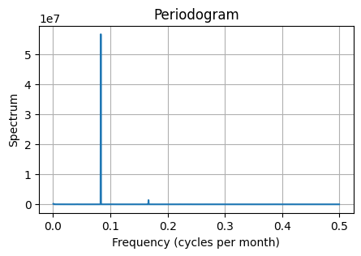

```
12.0
```

```python
la_monthly['Monthly_Absolute'] = la_monthly['Monthly_Absolute'].dropna()
print(la_monthly['Monthly_Absolute'].isna().sum())

power_spectrum = np.abs(fft(la_monthly['Monthly_Absolute'].to_numpy())) ** 2
frequencies = fftfreq(len(la_monthly['Monthly_Absolute'].to_numpy()), 1)

plt.figure(figsize=(5, 3))
plt.plot(frequencies[frequencies > 0], power_spectrum[frequencies > 0])
plt.title('Periodogram')
plt.xlabel('Frequency (cycles per month)')
plt.ylabel('Spectrum')
plt.grid()
plt.show()

max_index = np.argmax(power_spectrum[frequencies > 0])
ideal_period = 1 / frequencies[frequencies > 0][max_index]
print(ideal_period)
```

On the periodogram, there are a couple of visible peaks, but as calculated by the code above, the most prominent peak is suggesting a 12-month (1-year) period. I will use $s=12$ later in the SARIMA $(p,d,q)\times(P,D,Q)$ model.

# SARIMA Model

## Plotting the Time Series and Unit Root Testing

The first step of SARIMA model fitting is to plot the original data. Inspecting the plot can produce much insight into the stationarility and seasonality of the data.

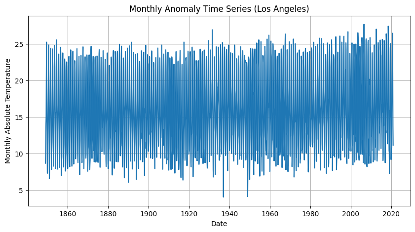

```python
plt.figure(figsize=(10, 5))
plt.plot(la_monthly.index, la_monthly['Monthly_Absolute'])
plt.title('Monthly Anomaly Time Series (Los Angeles)')
plt.xlabel('Date')
plt.ylabel('Monthly Absolute Temperature')
plt.grid(True)
plt.show()
```

Given the abundance of data points in this dataset, it is not a responsible idea to claim if it is stationary based on the graph. I will use the unit root testing / (augmented) Dickey-Fuller test. For efficiency, I will produce a couple of variations of the data ($\nabla x_t$, $\nabla_{12}x_t$, and $\nabla_{12} \nabla x_t$).

```python
la_monthly.loc[:, 'Diff'] = la_monthly['Monthly_Absolute'].diff()
la_monthly.loc[:, 'Diff_s12'] = la_monthly['Monthly_Absolute'].diff(12)
la_monthly.loc[:, 'Diff_Diff_s12'] = la_monthly['Diff'].diff(12)
adf0, p0, user_lag0, n_obs0, critical_values0, icbest0 = adfuller(la_monthly['Monthly_Absolute'].dropna())
adf1, p1, user_lag1, n_obs1, critical_values1, icbest1 = adfuller(la_monthly['Diff'].dropna())
adf2, p2, user_lag2, n_obs2, critical_values2, icbest2 = adfuller(la_monthly['Diff_s12'].dropna())
adf3, p3, user_lag3, n_obs3, critical_values3, icbest3 = adfuller(la_monthly['Diff_Diff_s12'].dropna())
print(p0<0.05, p1<0.05, p2<0.05, p3<0.05)
```

```
True True True True
```

## Plotting ACF and PACF

To our surprise, the augmented Dickey-Fuller test shows that even the original data is stationary. Then, in the next step, ACF and PACF are generated.

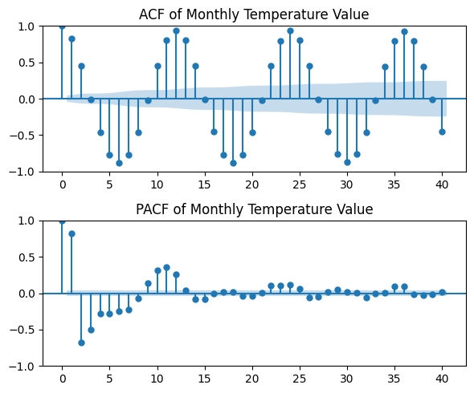

```python
fig, axs = plt.subplots(2, 1, figsize=(6, 5))

plot_acf(la_monthly['Monthly_Absolute'].dropna(), ax=axs[0], lags=40)
axs[0].set_title('ACF of Monthly Temperature Value')

plot_pacf(la_monthly['Monthly_Absolute'].dropna(), ax=axs[1], lags=40)
axs[1].set_title('PACF of Monthly Temperature Value')

plt.tight_layout()
plt.show()
```

Interpreting from this ACF and PACF plots:

- Seasonal: ACF tails off while PACF cuts off after $2s$, suggesting SAR(2).
- Non-seasonal: ACF tails off and PACF tails off within the first $1s$. This is vague, but ARMA(2,2) can be a good starting point.

The starting point of model fitting is $\text{SARIMA}(2,0,2)\times(2,0,0)_{12}$.

## Model Fitting and Diagnostics

```python
def diagnostic_plots(fitting_results, title_suffix=''):
    fig, axes = plt.subplots(2, 2, figsize=(12, 8))

    # 1. Standardized Residual vs Time Plot
    axes[0, 0].plot(fitting_results.resid, linestyle='-', markersize=3)
    axes[0, 0].set_title('Standardized Residuals' + title_suffix)
    axes[0, 0].set_xlabel('Time')
    axes[0, 0].set_ylabel('Standardized Residuals')
    axes[0, 0].grid(True)

    # 2. ACF of Residuals vs Lag Plot
    plot_acf(fitting_results.resid, lags=40, zero=False, ax=axes[0, 1])
    axes[0, 1].set_ylim(-0.1, 0.1)
    axes[0, 1].set_title('ACF of Residuals vs Lag' + title_suffix)
    axes[0, 1].set_xlabel('Lag')
    axes[0, 1].set_ylabel('ACF')
    axes[0, 1].grid(True)

    # 3. Normal Q-Q Plot of Standardized Residuals
    qqplot(fitting_results.resid, line='s', ax=axes[1, 0])
    axes[1, 0].set_title('Normal Q−Q Plot of Standardized Residuals' + title_suffix)
    axes[1, 0].grid(True)

    # 4. p-values of Ljung-Box Statistics
    lb_test = acorr_ljungbox(fitting_results.resid, lags=40, return_df=True)
    p_values = lb_test['lb_pvalue']
    axes[1, 1].plot(p_values, marker='o', linestyle='-')
    axes[1, 1].axhline(y=0.05, color='r', linestyle='--')
    axes[1, 1].set_title('p-values for Ljung-Box Statistic vs Lag' + title_suffix)
    axes[1, 1].set_xlabel('Lag')
    axes[1, 1].set_ylabel('p-value')
    axes[1, 1].grid(True)

    plt.tight_layout()
    plt.show()
```

`model1` is the $\text{SARIMA}(2,0,2)\times(2,0,0)_{12}$ model discussed above.

```
                                      SARIMAX Results
===========================================================================================
Dep. Variable:                    Monthly_Absolute   No. Observations:                 2064
Model:             SARIMAX(2, 0, 2)x(2, 0, [], 12)   Log Likelihood               -3703.986
Date:                             Thu, 13 Jun 2024   AIC                           7421.972
Time:                                     23:41:01   BIC                           7461.310
Sample:                                 01-01-1849   HQIC                          7436.402
                                      - 12-01-2020
Covariance Type:                               opg
==============================================================================
                 coef    std err          z      P>|z|      [0.025      0.975]
------------------------------------------------------------------------------
ar.L1          1.2242      0.100     12.236      0.000       1.028       1.420
ar.L2         -0.2241      0.100     -2.240      0.025      -0.420      -0.028
ma.L1         -1.0168      0.724     -1.404      0.160      -2.436       0.403
ma.L2          0.0168      0.104      0.162      0.871      -0.187       0.220
ar.S.L12       0.5045      0.018     27.587      0.000       0.469       0.540
ar.S.L24       0.4559      0.019     24.427      0.000       0.419       0.492
sigma2         2.2106      1.563      1.415      0.157      -0.852       5.273
===================================================================================
Ljung-Box (L1) (Q):                   0.08   Jarque-Bera (JB):                14.00
Prob(Q):                              0.78   Prob(JB):                         0.00
Heteroskedasticity (H):               1.85   Skew:                            -0.13
Prob(H) (two-sided):                  0.00   Kurtosis:                         3.30
===================================================================================

Warnings:
[1] Covariance matrix calculated using the outer product of gradients (complex-step).
```

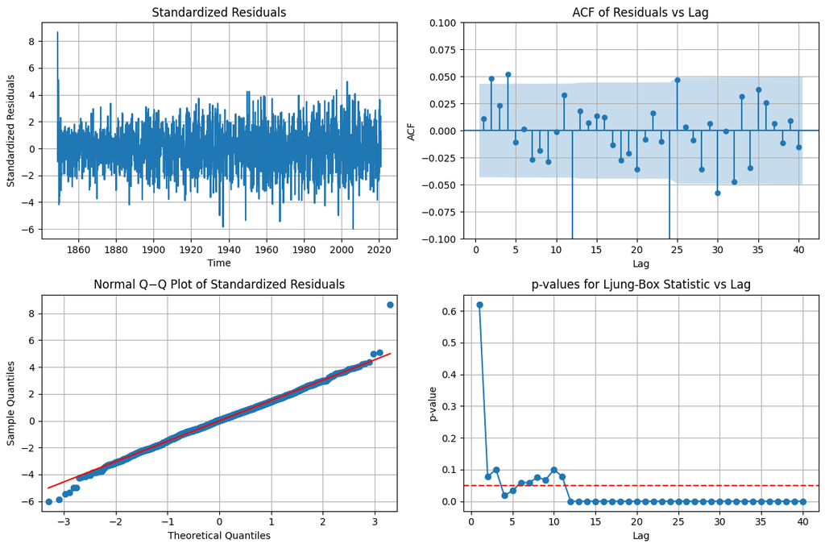

```python
model1 = SARIMAX(la_monthly['Monthly_Absolute'],
                order=(2, 0, 2),
                seasonal_order=(2, 0, 0, 12),
                enforce_stationarity=False,
                enforce_invertibility=False)
fitting_results1 = model1.fit(disp=False)
print(fitting_results1.summary())
diagnostic_plots(fitting_results1)
```

The $\theta_1$ and $\theta_2$ are not significant. In an attempt to drop these two parameters, I will then plot $\text{SARIMA}(2,0,0)\times(2,0,0)_{12}$ (`model2`).

```
                                     SARIMAX Results
==========================================================================================
Dep. Variable:                   Monthly_Absolute   No. Observations:                 2064
Model:             SARIMAX(2, 0, 0)x(2, 0, 0, 12)   Log Likelihood               -3711.137
Date:                            Thu, 13 Jun 2024   AIC                           7432.274
Time:                                    23:41:03   BIC                           7460.373
Sample:                                01-01-1849   HQIC                          7442.581
                                     - 12-01-2020
Covariance Type:                              opg
==============================================================================
                 coef    std err          z      P>|z|      [0.025      0.975]
------------------------------------------------------------------------------
ar.L1          0.1916      0.021      8.970      0.000       0.150       0.233
ar.L2          0.0472      0.021      2.231      0.026       0.006       0.089
ar.S.L12       0.5238      0.018     29.037      0.000       0.488       0.559
ar.S.L24       0.4725      0.018     26.023      0.000       0.437       0.508
sigma2         2.2346      0.065     34.130      0.000       2.106       2.363
===================================================================================
Ljung-Box (L1) (Q):                   0.02   Jarque-Bera (JB):                11.01
Prob(Q):                              0.90   Prob(JB):                         0.00
Heteroskedasticity (H):               1.85   Skew:                            -0.08
Prob(H) (two-sided):                  0.00   Kurtosis:                         3.32
===================================================================================

Warnings:
[1] Covariance matrix calculated using the outer product of gradients (complex-step).
```

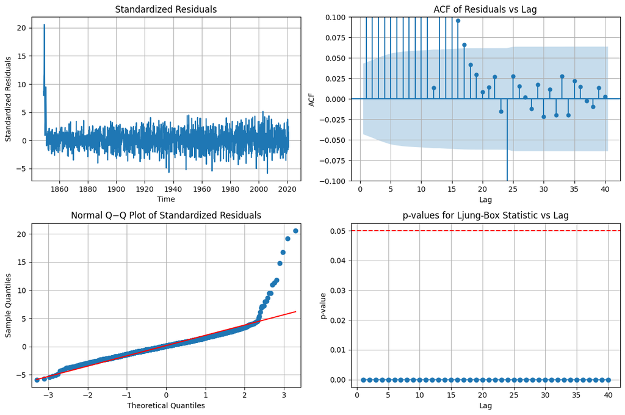

```python
model2 = SARIMAX(la_monthly['Monthly_Absolute'],
                order=(2, 0, 0),
                seasonal_order=(2, 0, 0, 12),
                enforce_stationarity=False,
                enforce_invertibility=False)
fitting_results2 = model2.fit(disp=False)
print(fitting_results2.summary())
diagnostic_plots(fitting_results2)
```

All four diagnostic plots have shown a lot of abnormalities. In this case, this model will not be considered. The next step is to fit $\text{SARIMA}(1,0,1)\times(2,0,0)_{12}$ (`model3`) and $\text{SARIMA}(1,0,0)\times(2,0,0)_{12}$ (`model4`).

```
                                      SARIMAX Results
===========================================================================================
Dep. Variable:                    Monthly_Absolute   No. Observations:                 2064
Model:             SARIMAX(1, 0, 1)x(2, 0, [], 12)   Log Likelihood               -3711.092
Date:                             Thu, 13 Jun 2024   AIC                           7432.183
Time:                                     23:41:06   BIC                           7460.284
Sample:                                 01-01-1849   HQIC                          7442.491
                                      - 12-01-2020
Covariance Type:                               opg
==============================================================================
                 coef    std err          z      P>|z|      [0.025      0.975]
------------------------------------------------------------------------------
ar.L1          0.5555      0.080      6.984      0.000       0.400       0.711
ma.L1         -0.3763      0.089     -4.215      0.000      -0.551      -0.201
ar.S.L12       0.5235      0.018     29.059      0.000       0.488       0.559
ar.S.L24       0.4723      0.018     26.035      0.000       0.437       0.508
sigma2         2.2304      0.065     34.138      0.000       2.102       2.358
===================================================================================
Ljung-Box (L1) (Q):                   0.11   Jarque-Bera (JB):                11.57
Prob(Q):                              0.74   Prob(JB):                         0.00
Heteroskedasticity (H):               1.87   Skew:                            -0.08
Prob(H) (two-sided):                  0.00   Kurtosis:                         3.33
===================================================================================

Warnings:
[1] Covariance matrix calculated using the outer product of gradients (complex-step).
```

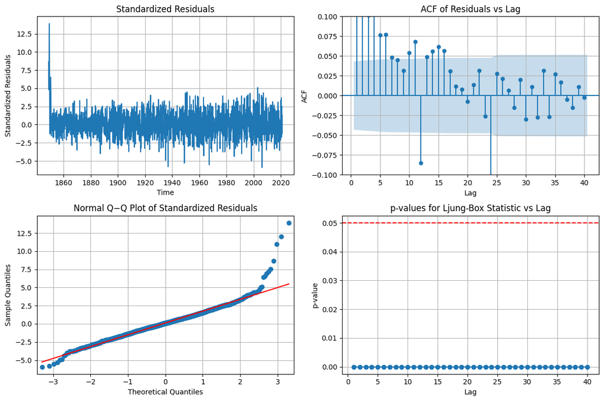

```python
model3 = SARIMAX(la_monthly['Monthly_Absolute'],
                order=(1, 0, 1),
                seasonal_order=(2, 0, 0, 12),
                enforce_stationarity=False,
                enforce_invertibility=False)
fitting_results3 = model3.fit(disp=False)
print(fitting_results3.summary())
diagnostic_plots(fitting_results3)
```

```
                                     SARIMAX Results
==========================================================================================
Dep. Variable:                   Monthly_Absolute   No. Observations:                 2064
Model:             SARIMAX(1, 0, 0)x(2, 0, 0, 12)   Log Likelihood               -3714.874
Date:                            Thu, 13 Jun 2024   AIC                           7437.748
Time:                                    23:41:07   BIC                           7460.229
Sample:                                01-01-1849   HQIC                          7445.995
                                     - 12-01-2020
Covariance Type:                              opg
==============================================================================
                 coef    std err          z      P>|z|      [0.025      0.975]
------------------------------------------------------------------------------
ar.L1          0.2008      0.021      9.604      0.000       0.160       0.242
ar.S.L12       0.5230      0.018     29.069      0.000       0.488       0.558
ar.S.L24       0.4737      0.018     26.159      0.000       0.438       0.509
sigma2         2.2387      0.066     34.147      0.000       2.110       2.367
===================================================================================
Ljung-Box (L1) (Q):                   0.24   Jarque-Bera (JB):                10.19
Prob(Q):                              0.63   Prob(JB):                         0.01
Heteroskedasticity (H):               1.85   Skew:                            -0.07
Prob(H) (two-sided):                  0.00   Kurtosis:                         3.32
===================================================================================

Warnings:
[1] Covariance matrix calculated using the outer product of gradients (complex-step).
```

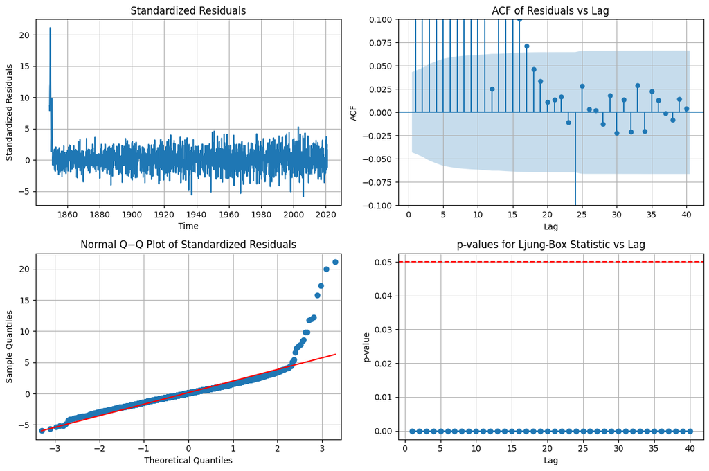

```python
model4 = SARIMAX(la_monthly['Monthly_Absolute'],
                order=(1, 0, 0),
                seasonal_order=(2, 0, 0, 12),
                enforce_stationarity=False,
                enforce_invertibility=False)
fitting_results4 = model4.fit(disp=False)
print(fitting_results4.summary())
diagnostic_plots(fitting_results4)
```

The `model2`, `model3`, and `model4` have all exhibited serious problems with the diagnostic plots. Now, I try $\text{SARIMA}(2,0,1)\times(2,0,0)_{12}$ (`model5`).

```
                                      SARIMAX Results
===========================================================================================
Dep. Variable:                    Monthly_Absolute   No. Observations:                 2064
Model:             SARIMAX(2, 0, 1)x(2, 0, [], 12)   Log Likelihood               -3708.563
Date:                             Thu, 13 Jun 2024   AIC                           7429.126
Time:                                     23:41:10   BIC                           7462.844
Sample:                                 01-01-1849   HQIC                          7441.495
                                      - 12-01-2020
Covariance Type:                               opg
==============================================================================
                 coef    std err          z      P>|z|      [0.025      0.975]
------------------------------------------------------------------------------
ar.L1          0.7884      0.197      3.996      0.000       0.402       1.175
ar.L2         -0.0629      0.053     -1.186      0.236      -0.167       0.041
ma.L1         -0.6013      0.196     -3.072      0.002      -0.985      -0.218
ar.S.L12       0.5221      0.018     28.878      0.000       0.487       0.558
ar.S.L24       0.4735      0.018     26.024      0.000       0.438       0.509
sigma2         2.2285      0.065     34.089      0.000       2.100       2.357
===================================================================================
Ljung-Box (L1) (Q):                   0.00   Jarque-Bera (JB):                11.38
Prob(Q):                              0.98   Prob(JB):                         0.00
Heteroskedasticity (H):               1.87   Skew:                            -0.08
Prob(H) (two-sided):                  0.00   Kurtosis:                         3.33
===================================================================================

Warnings:
[1] Covariance matrix calculated using the outer product of gradients (complex-step).
```

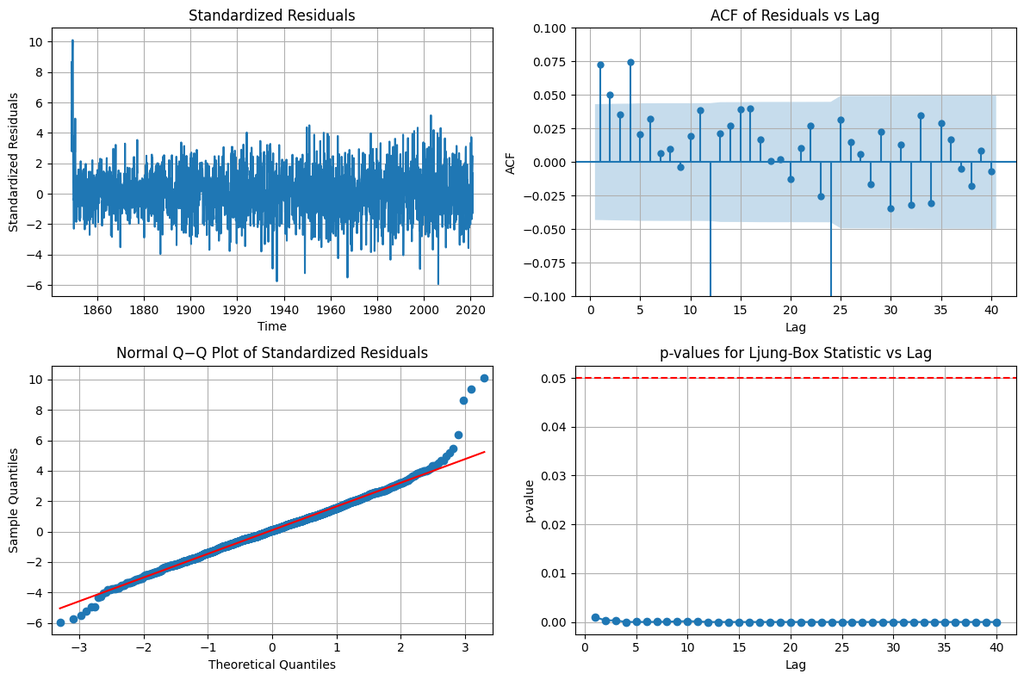

```python
model5 = SARIMAX(la_monthly['Monthly_Absolute'],
                order=(2, 0, 1),
                seasonal_order=(2, 0, 0, 12),
                enforce_stationarity=False,
                enforce_invertibility=False)
fitting_results5 = model5.fit(disp=False)
print(fitting_results5.summary())
diagnostic_plots(fitting_results5)
```

## Model Selection

The AIC, BIC, AICc values are presented in the table below.

[output not shown]

The general methodology of model selection is straightforward: In addition to choosing the model of the lowest AIC, BIC, and AICc,

- Prioritize models with good diagnostic plots.
- Among models with good diagnostics, prefer those with significant parameters.

Hence, $\text{ARIMA}(2,0,2)\times(2,0,0)_{12}$ is chosen.

# Forecasting

Using the selected model to produce the next 12-month's temperature forecast near Los Angeles.

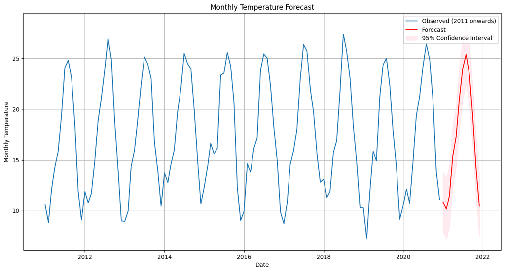

```python
forecast_steps = 12
forecast = fitting_results1.get_forecast(steps=forecast_steps)
forecast_values = forecast.predicted_mean
forecast_conf_int = forecast.conf_int()

plt.figure(figsize=(15, 7.5))
start_zoom = '2011-01-01'
end_zoom = forecast_values.index[-1]
plt.plot(la_monthly.loc[start_zoom:end_zoom].index,
la_monthly.loc[start_zoom:end_zoom]['Monthly_Absolute'],
label='Observed (2011 onwards)')
plt.plot(forecast_values.index, forecast_values, color='red', label='Forecast')
plt.fill_between(forecast_conf_int.index,
forecast_conf_int.iloc[:, 0],
forecast_conf_int.iloc[:, 1],
color='pink',
alpha=0.3,
label='95% Confidence Interval')
plt.title('Monthly Temperature Forecast')
plt.xlabel('Date')
plt.ylabel('Monthly Temperature')
plt.legend()
plt.grid(True)
plt.show()
```